# OHI and R Tutorials

# R Tutorials Introduction

Ocean Health Index R code uses several packages and best practices to faciliate understanding and collaboration. These approaches are presented here, along with examples using data included in global OHI assessments.

This document describes several packages that are used extensively in OHI assessments and introduces you to typical coding practices commonly seen in OHI scripts and functions.

Also see the accompanying R script to test examples using these packages.

## R Very Basics:

- Have you already downloaded and installed [R](http://www.r-project.org/)?
- Have you already downloaded and installed [RStudio](http://www.rstudio.com/)?
- Have you walked through the excellent interactive tutorials from [swirl](http://swirlstats.com/students.html)?

# `tidyr` functions

‘Tidy’ up your messy data using `tidyr` to make it easier to work with. The ‘tidy tools’ functions in the `dplyr` package work best with tidy data.

From Hadley Wickham’s [*Tidy Data* paper:](http://vita.had.co.nz/papers/tidy-data.html) >It is often said that 80% of data analysis is spent on the cleaning and preparing data. And it’s not just a first step, but it must be repeated many over the course of analysis as new problems come to light or new data is collected. To get a handle on the problem, this paper focuses on a small, but important, aspect of data cleaning that I call data tidying: structuring datasets to facilitate analysis.

From [RStudio’s introduction to `tidyr`](http://blog.rstudio.org/2014/07/22/introducing-tidyr/):

> The two most important properties of tidy data are: * Each column is a variable. * Each row is an observation.

> Arranging your data in this way makes it easier to work with because you have a consistent way of referring to variables (as column names) and observations (as row indices). When you use tidy data and tidy tools, you spend less time worrying about how to feed the output from one function into the input of another, and more time answering your questions about the data.

Install `tidyr`:

```
install.packages('tidyr')
library(tidyr)
```

Follow directions on intro to download sample data used in these examples.

`gather()` is arguably the most useful function in `tidyr`, and is explained in more detail below. `spread()` and `separate()` are other useful functions in `tidyr`.

Other ‘tidyr’ references: * [Hadley Wickham’s *Tidy Data* paper:](http://vita.had.co.nz/papers/tidy-data.html) Download the pre-print version for the whys and hows of tidy data. * [Cran tidy data vignette:](http://cran.r-project.org/web/packages/tidyr/vignettes/tidy-data.html) An informal and code heavy version of Hadley’s full *Tidy Data* paper. * [RStudio Blogs: Introducing tidyr:](http://blog.rstudio.org/2014/07/22/introducing-tidyr/) Basics and philosophy of `tidyr` * [swirl tutorial package:](http://swirlstats.com/students.html) A tutorial package built directly into R. Section 2: ‘Getting and Cleaning Data’ runs you through `dplyr` and `tidyr` basics * [R data wrangling cheat sheet:](http://www.rstudio.com/wp-content/uploads/2015/02/data-wrangling-cheatsheet.pdf) A quick reference guide to `tidyr` and `dplyr` functions

## tidyr::gather()

### Description

`gather()` takes data organized in rows and collapses them into a column format (a key column and a value column), duplicating all other columns as needed. Use `gather()` when your data is organized in “wide” format, in which some of your variables are in row form, rather than column form. Another `tidyr` function, `spread()`, is more or less the reverse of `gather()`, to reformat long data into wide data. It is more difficult to work with wide data, but may be more convenient for examining data in a table format.

Note: `gather()` essentially replaces `melt()` in `plyr` package.

### Example

The sample data set (see intro) contains harvest data of a number of marine commodities, separated by country, commodity, and year. In its original form, the harvest data (in tonnes) is spread across five different harvest years. * Counter to ‘tidy data’ principles, we have multiple columns (X2007:X2011) representing a single variable (year), and multiple observations of harvest tonnage in each row. * To transform this into ‘tidy data’ we will gather the five annual harvests into a single column called ‘tonnes’ and note the year of harvest in a new column called ‘year’.

In this example (see figure), the original wide data is transformed into long data using the command:

```
data_long <- data_wide %>% gather(year, tonnes, X2007:X2011)
  ### Gathers columns X2007 through X2011 into a single column called 'year';
  ### the values from each column are put into a new column called 'tonnes'.

data_long <- data_wide %>% gather(year, tonnes, -Country, -Commodity, -Trade)
  ### Same results; the '-' unselects the named columns, so they will not
  ### be gathered; all other columns are gathered into 'year' and 'tonnes'.
```

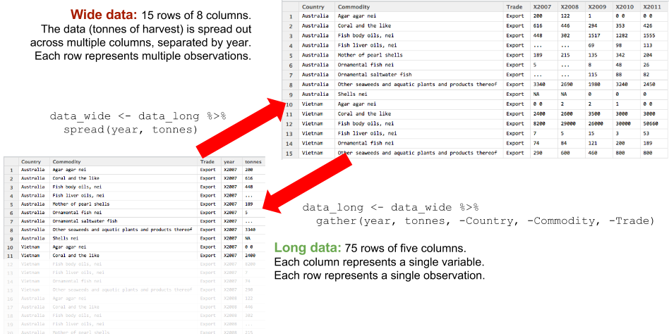

Now that the data is tidy, we can use `dplyr` package functions to further wrangle and analyze the data: `dplyr` tutorial

# `dplyr` functions

The `dplyr` package includes a number of functions to easily, quickly, and intuitively wrangle your data. Here is a quick introduction with examples from data used in the Ocean Health Index.

From [RStudio’s introduction to `dplyr`](http://blog.rstudio.org/2014/01/17/introducing-dplyr/):

> The bottleneck in most data analyses is the time it takes for you to figure out what to do with your data, and `dplyr` makes this easier by having individual functions that correspond to the most common operations…

> Each function does one only thing, but does it well.

Install `dplyr`:

```
install.packages('dplyr')
library(dplyr)
```

Follow directions on intro to download sample data used in these examples.

The most important `dplyr` functions to understand for data processing will be `group_by()`, `mutate()`, and `summarize()`. Also important, `dplyr` introduces the ability to perform subsequent functions in a logical and intuitive manner, using the `%>%` chain operator.

- `%>%` (chaining operator): allows sequential chaining of functions for cleaner, easier-to-read code
- `dplyr::select()`: selects variables to be retained or dropped from dataset
- `dplyr::filter()`: filters data set by specified criteria
- `dplyr::arrange()`: sorts dataset by specified variables
- `dplyr::mutate()`: adds variables or modifies existing variables
- `dplyr::summarize()`: uses analysis functions (sum, mean, etc) to summarize/aggregate specified variables
- `dplyr::group_by()`: groups data by specified variables, allowing for group-level data processing.

Other `dplyr` references:

- [RStudio blogs: Introducing dplyr:](http://blog.rstudio.org/2014/01/17/introducing-dplyr/): philosophy, examples, and basics of `dplyr`
- [Cran dplyr vignette:](http://cran.rstudio.com/web/packages/dplyr/vignettes/introduction.html) Walkthrough of `dplyr` with examples
- [`dplyr` and pipes: the basics:](http://seananderson.ca/2014/09/13/dplyr-intro.html) More examples of `dplyr` functions, and more depth on `%>%`
- [swirl tutorial package:](http://swirlstats.com/students.html) A tutorial package built directly into R. Section 2: ‘Getting and Cleaning Data’ runs you through `dplyr` and `tidyr` basics
- [R data wrangling cheat sheet:](http://www.rstudio.com/wp-content/uploads/2015/02/data-wrangling-cheatsheet.pdf) a quick reference guide to `tidyr` and `dplyr` functions

## %>% operator

### Description

The `%>%` operator allows you to ‘pipe’ or ‘chain’ a number of function calls, in which the output dataframe of one function is fed directly into the next function as the input dataframe. This lets you avoid creating temporary variables to store intermediate values, and lets you avoid nesting multiple functions. Using `%>%` makes your code more elegant, streamlined, and easy to read since you are able to write your code on multiple indented lines. From [`dplyr` and pipes: the basics:](http://seananderson.ca/2014/09/13/dplyr-intro.html)

> OK, here’s where it gets cool. We can chain `dplyr` functions in succession. This lets us write data manipulation steps in the order we think of them and avoid creating temporary variables in the middle to capture the output. This works because the output from every `dplyr` function is a data frame and the first argument of every `dplyr` function is a data frame.

### Usage

```
data_out <- f(data_in, args)
  ### standard function call

data_out <- data_in %>% f(args)
  ### function call using %>% operator. data_in is passed as first argument
  ### of function().

data_out <- data_in %>%
  f1(args1) %>%
  f2(args2) %>%
  f3(args3) %>% ...
  ### Output of function can be passed to another function immediately,
  ### without need for temporary storage. Indented format for legibility,
  ### see how pretty it looks?
```

### Example

```
### Bad!  Nested functions: read from inside out - hard to decipher
  h_recent_totals1 <- arrange(mutate(filter(group_by(harvest, country, commodity),
    year >= 2009), harvest_tot = sum(tonnes, na.rm = TRUE)), country, commodity)

### Better: Line by line. Easier to read, but have to wait for the end to see
### what it does.  Temp variables add more places for errors and bugs.
  h_temp <- group_by(harvest, country, commodity)
  h_temp <- filter(h_temp, year >= 2009)
  h_temp <- mutate(h_temp, harvest_tot = sum(tonnes, na.rm = TRUE))
  h_recent_totals2 <- arrange(h_temp, country, commodity)

### Best!  Chained format intuitively links together the functions. Saves
### typing, fewer opportunities for errors, easier to debug. The %>% operator
### automatically indents each following line for easy reading.
  h_recent_totals3 <- harvest %>%
    group_by(country, commodity) %>%
    filter(year >= 2009) %>%
    mutate(harvest_tot = sum(tonnes, na.rm = TRUE)) %>%
    arrange(country, commodity)
```

## dplyr::select()

### Description

`select()` allows you to choose specific columns/variables from your dataset, and drop all others. Alternately, you can select specific variables to drop, leaving others in place. `rename()` is a relative of `select()` that allows you to rename variables, while leaving all variables in place.

### Example

The sample dataset includes the annual harvest, in tonnes, of a number of commodities exported by two countries. Type of trade provides no information (it is all Export), so that variable can be dropped. The names of all the variables should be converted to lower-case, to match the OHI style guide. See the figure below.

```
### Example 1:
harvest <- harvest %>%
  select(Country, Commodity, year, tonnes)
  ### Selects the named variables, and drops all others.  Useful to choose a
  ### subset of key variables from a complicated data set.

### Example 2 (same result as example 1):
harvest <- harvest %>%
  select(-Trade)
  ### Using the '-' drops 'Trade' column and leaves other variables intact.
  ### Useful if you would like to clear out temporary variables.

harvest <- harvest %>%
  rename(country = Country, commodity = Commodity)
  ### Drops no variables. Syntax: rename(new_var_name = old_var_name) w/o quotes.
```

Using the chain operator, we can string these two functions into one smooth, easy-to-read flow:

```
harvest1 <- harvest %>%
  select(-Trade) %>%
  rename(country = Country, commodity = Commodity)
```

The `harvest` data is fed into `select()`, and the output is fed into `rename()`. The final output of this complete flow is assigned to the new variable `harvest1`.

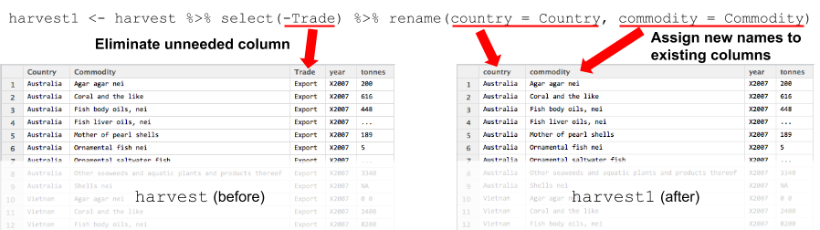

## dplyr::filter()

### Description

`filter()` allows you to select observations (rows) that match search criteria, using values in specified variables (columns). Drops all observations that do not match the criteria. * Use logical operators & and | to filter on multiple criteria simultaneously

### Example

```
harvest_vnm  <- harvest %>%
  filter(country == 'Vietnam')
  ### Single criterion filter: keeps only data with country matching 'Vietnam'.

h_vnm_recent <- harvest %>%
  filter(country == 'Vietnam' & year >= 2009)
  ### filter with multiple criteria: selects 'Vietnam' data from 2009 or later.
```

## dplyr::arrange()

### Description

`arrange()` sorts observations (rows) based upon a specified variable or list of variables. Does not actually change the data in any way, only the appearance. Useful for inspecting your data after each processing step.

### Example

```
harvest_sorted <- harvest %>%
  arrange(country, commodity, year)
  ### Sorts commodity harvest values for each country, chronologically

harvest_sorted <- harvest %>%
  arrange(country, commodity, desc(year))
  ### Sorts harvest values by most recent year (descending order)
```

## dplyr::mutate()

### Description

`mutate()` is a powerful and useful tool for processing data. You can add new variables or modify existing variables, using all variety of functions to perform operations on the dataset. `mutate()` works well with `group_by()` to perform calculations and analysis at a group level rather than dataset level.

### Example

From the sample data set (see figure below), we would like to: * Remove the ‘X’ from the ‘year’ values. * Translate the text codes in ‘tonnes’ into numbers and NAs. These codes are specific to FAO’s data reporting format: `...` is the same as `NA`, and `0 0` means greater than zero, but less than half a tonne. * Convert these text fields into numeric fields so they can be analyzed properly.

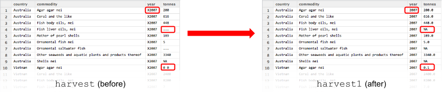

```
library(stringr)   ### to access 'str_replace()' string functions

harvest1 <- harvest %>%
  mutate(
    year   = str_replace(year,   fixed('X'),    ''),  # remove the 'X'
    tonnes = str_replace(tonnes, fixed('...'),  NA),  # replace '...' with 'NA'
    tonnes = str_replace(tonnes, fixed('0 0'), 0.1),  # replace '0 0' with '0.1'
    tonnes = ifelse(tonnes =='', NA, tonnes)) %>%
  mutate(
    tonnes = as.numeric(as.character(tonnes)),
    year   = as.integer(as.character(year)))
```

Notes: * In this example, no new variables were added. Multiple variables can be changed with one call to `mutate()`. Multiple modifications to ‘tonnes’ happen sequentially, so order is important. * The `as.numeric(as.character(...))` gets around the fact that these text variables are stored as ‘factor’ class, rather than ‘character’ class. `as.character()` forces them into character class, and then the `as.numeric()` can convert the character strings to numeric where applicable. Similar for `as.integer(...)`

## dplyr::summarize()

### Description

`summarize()` combines multiple values of a variable into a single summary value. `summarize()` works well with `group_by()` - for grouped data, each group will be summarized and reported separately. For ungrouped data, the summary covers the entire dataset. * `summarize()` compresses the dataset and drops individual observations. To maintain individual observations, consider creating a summary variable using `mutate()` instead. * `NA` values can be problematic - use `na.rm=TRUE` or similar methods.

### Example

To determine the total harvest of each country, for each commodity:

```
h_summary <- harvest %>%
  group_by(country, commodity) %>%
  summarize(harvest_tot = sum(tonnes, na.rm = TRUE)) %>%
  ungroup()
```

## dplyr::group_by()

### Description

`group_by()` allows you to easily group a dataset by one or more variables/columns.  
By itself, it does nothing to change your data. But once your dataset has been sorted into useful groups, other `dplyr` functions will operate on each group separately, rather than operating on the entire dataset. * The function `groups(data)` reports back the current grouping status of dataframe `data`.  
* `group_by()` alters the grouping, but does not alter the sort order.  
`arrange()` does not alter the current grouping - it will sort by groups first, then sorts within each group. * Multiple calls to `group_by()` will reset the groupings each time (by default), rather than adding additional layers of groups. * Once you have finished with your operation at the group level, it is a good practice to use the `ungroup()` function to remove the groupings, to avoid unintended consequences due to forgotten `group_by()` calls.

### Example

If you want to find the total tonnage harvested for each commodity for each country, you would want to group by country and by commodity, and then perform a `sum()` function on the grouped data. Two options presented here: `summarize()` to collapse data to just the summary, and `mutate()` to add a new column that includes the summary values.

[output not shown]

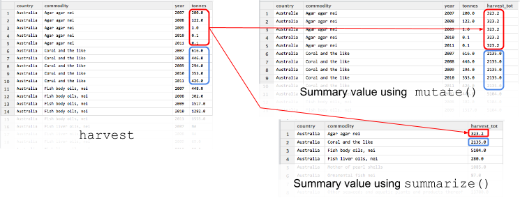